# 思路

主要就是三个步骤。

1. 创建小部件
2. 将小部件和函数参数关联，或者相互关联，调控参数
3. 调整布局

## 创建小部件

有许多小部件的函数。都是直接在ipywidgets下的.

### 小部件的展示与关闭

小部件虽然大多数情况可以直接展示，但是也可以用display函数，`from IPython.display import display`,并且对于同一个widget，多次display会出现多个保持同步的相同widget。

小部件拥有close方法，使用widget.close()来关闭一个widget

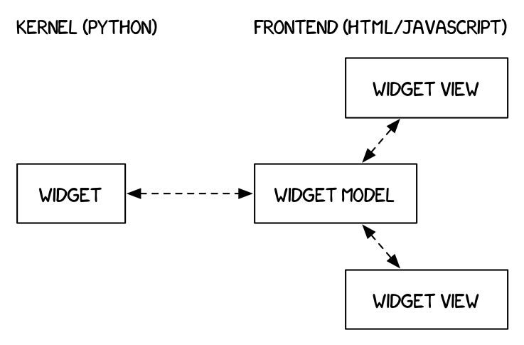

```python
Numeral=['IntSlider','FloatSlider','FloatLogSlider','IntRangeSlider','FloatRangeSlider','IntProgress','FloatProgress',
         'BoundedIntText','BoundedFloatText','IntText','FloatText']
Boolean=['ToggleButton','Checkbox','Valid','']
Selection=['Dropdown','RadioButtons','Select','SelectionSlider','SelectionRangeSlider','ToggleButtons','SelectMultiple']
Text=['Text','Textarea','Combobox','Label','HTML','HTMLMath','Image','Button']
Output=['Play','DatePicker','ColorPicker','FileUpload','Controller']
Container=['Box','HBox','VBox','GridBox','Accordion','Tab']
from IPython.display import display
import ipywidgets as widgets
from ipywidgets import Tab,Accordion,HBox,VBox,Layout,Dropdown,interactive_output
widget_kind=['Numeral','Boolean','Selection','Text','Output','Container']
def widget_help(widget):
    if widget:
        help(eval('widgets.'+widget))
outNumeral=widgets.Output()
@outNumeral.capture(clear_output=True)
def out_Numeral(widget):
    display(eval('widgets.'+widget['new']+"(layout=Layout(width='auto'))"))
outBoolean=widgets.Output()
@outBoolean.capture(clear_output=True)
def out_Boolean(widget):
    display(eval('widgets.'+widget['new']+"(layout=Layout(width='auto'),value=True)"))
outSelection=widgets.Output()
@outSelection.capture(clear_output=True)
def out_Selection(widget):
    if widget['new']!='SelectionRangeSlider' and widget['new']!='SelectMultiple':
        display(eval('widgets.'+widget['new']+"(layout=Layout(width='auto'),options=['a','b','c','d'] ,value='a')"))
    else:
        display(eval('widgets.'+widget['new']+"(layout=Layout(width='auto'),options=['a','b','c','d'] ,value=('b','c'))"))
outText=widgets.Output()
@outText.capture(clear_output=True)
def out_Text(widget):
    if widget['new']!='Image':
        display(eval('widgets.'+widget['new']+"(layout=Layout(width='auto'),value='hello world')"))
    else:
        display(eval('widgets.'+widget['new']+"(layout=Layout(width='auto'))"))
outOutput=widgets.Output()
@outOutput.capture(clear_output=True)
def out_Output(widget):
    display(eval('widgets.'+widget['new']+"(layout=Layout(width='auto'))"))
outContainer=widgets.Output()
@outContainer.capture(clear_output=True)
def out_Container(widget):
    display(eval('widgets.'+widget['new']+"(layout=Layout(width='auto'),children=[widgets.IntSlider(),widgets.Text(value='hello world')])"))
#out=widgets.Output(layout={'border': '1px solid black'})
children=[]
for i,kind in enumerate(widget_kind):
    locals()['tab'+kind]=Dropdown(options=eval(kind),value=eval(kind)[0],layout=Layout(width='auto'))
    eval('tab'+kind).observe(eval('out'+'_'+kind),names='value')
    #children.append(HBox(children=[VBox(children=[eval('tab'+kind),eval('widgets.'+str(eval('tab'+kind+'.value'),layout)+'()')]),interactive_output(widget_help,{'widget':eval('tab'+kind)})]))
    children.append(HBox(children=[VBox(children=[eval('tab'+kind),eval('out'+kind)],layout=Layout(width='30%')),interactive_output(widget_help,{'widget':eval('tab'+kind)})],layout=Layout(height='500px')))
tab=Tab(children=children,layout=Layout(height='400px'))
for i,kind in enumerate(widget_kind):
    tab.set_title(i,title=kind)
display(tab)
```

### 小部件的参数(keys)

大多数小部件都拥有keys(获得部件可设置参数),description（对部件的描述）,disabled参数(让部件不能变化)，

可以通过widget.keys查看一个widget的所有参数，不同的widget拥有不同的参数，并且这些参数可以直接利用属性获得，并且随着部件的变化而更新

# 定义互动

## 快捷方式

### interact

.interact()#传递函数，参数赋予一个小部件或小部件的缩写，传递的int，char等会被认为是小部件的缩写，转化为相应widget呈现。

| Keyword argument | Widget |
| --- | --- |
| `True` or `False` | Checkbox |
| `'Hi there'` | Text |
| `value` or `(min,max)` or `(min,max,step)` if integers are passed | IntSlider |
| `value` or `(min,max)` or `(min,max,step)` if floats are passed | FloatSlider |
| `['orange','apple']` or `[(‘one’, 1), (‘two’, 2)] | Dropdown |

结果直接呈现

### interactive

.interactive()

区别在于返回widget和output函数，结果不会直接呈现。可以用display函数呈现。

优点在于可以获取现在所有参数取值w.kwargs,以及结果w.result

**并且可以兼顾布局和manual，manual_name选项**，对象是一个包含所有widgets和interact button和output，output默认会在下次输出清空上次输出

可以自己定义output装饰器，这样会覆盖掉默认的output

```
w=interactive()
w.children#可以看到widgets等包含对象
w.children[-2].style.button_color='lightgreen'#设置interact button的style
```

### disable continuous updating

当你滑动滑块时，值也在更新，在大量数据时这很糟糕

When interacting with long running functions, realtime feedback is a burden instead of being helpful.

我们可以设置只在鼠标停止时更新

- interact_manual 手动互动，自己需要按下interact按钮，值才会更新
- interactive中添加字典参数{'manual': True}
- 当参数传递的是widget实例时，可以在widget中设置continuous_update

### interactive_output

可以事先设置widgets的布局，然后该对象就只会输出结果，我们可以把布局和输出放在一起，重新输出

不过需要传递的对象则必须是widget的实例了

## event and link

### .jslink

将某个部件的某个参数和另一个部件的某个参数相联系

调用widgets.jslink函数

mylink=widgets.jslink((widget0,'value'),(widget1,'value'))

unlink:调用link对象的unlink方法

mylink.unlink()

### .link and .dlink

only work in ipython

```
caption = widgets.Label(value='The values of slider1 and slider2 are synchronized')
sliders1, slider2 = widgets.IntSlider(description='Slider 1'),\
                    widgets.IntSlider(description='Slider 2')
l = widgets.link((sliders1, 'value'), (slider2, 'value'))
display(caption, sliders1, slider2)
```

### .onclick

独属于button widget的event，

button可以调用这个方法来call某个handler

```
from IPython.display import display
button = widgets.Button(description="Click Me!")
output = widgets.Output()

display(button, output)

def on_button_clicked(b):
    with output:
        print("Button clicked.")

button.on_click(on_button_clicked)
```

### .observe

Traitlet events

Widget properties are IPython traitlets and traitlets are eventful. To handle changes, the observe method of the widget can be used to register a callback. The doc string for observe can be seen below.

也就是widget的每个属性都可以看成一个事件，可以把某个属性或多个属性联系到某个函数

当widget发生变化时，会把变化传递到函数，函数应该有一个参数来接受这个变化，一般命名为change，change将会是一个字典。至少会有'type'和'name'键,代表设置的widget的type以及widget对应函数的参数名，比如value。

In the case where type is change, we also have the following keys:

owner : the HasTraits instance

old : the old value of the modified trait attribute

new : the new value of the modified trait attribute

name : the name of the modified trait attribute.

```python
import ipywidgets as widgets
w=widgets.IntSlider()
def f(change1):
    print(change1)
w.observe(f,names=['value','min'],type='change')
w
```

```python
x_widget = widgets.FloatSlider(min=0.0, max=10.0, step=0.05)
y_widget = widgets.FloatSlider(min=0.5, max=10.0, step=0.05, value=5.0)

def update_x_range(*args):
    x_widget.max = 2.0 * y_widget.value
y_widget.observe(update_x_range, 'value')

def printer(x, y):
    print(x, y)
widgets.interact(printer,x=x_widget, y=y_widget);
```

```python
x_widget = widgets.FloatSlider(min=0.0, max=10.0, step=0.05)
y_widget = widgets.FloatSlider(min=0.5, max=10.0, step=0.05, value=5.0)

def update_x_range(*args):
    x_widget.max = 2.0 * y_widget.value
y_widget.observe(update_x_range, 'value')
x_widget.observe(f,names=['value','max'])
def printer(x, y):
    print(x, y)
widgets.interact(printer,x=x_widget, y=y_widget);
```

# output

## 创建，添加实例

output也可以看做是一个widget

创建函数为 .output()

```
out = widgets.Output(layout={'border': '1px solid black'})
out
```

## 添加输出内容

我们可以把输出内容放到output中，包括capture and display stdout, stderr and rich output generated by IPython. You can also append output directly to an output widget, or clear it programmatically.

方法有

- **with output实例**

  ```
  with out:
     里面的输出都会输出到output中
  ```

After the widget is created, direct output to it using a context manager. You can print text to the output area:

Rich output can also be directed to the output area. Anything which displays nicely in a Jupyter notebook will also display well in the Output widget.

We can even display complex mimetypes, such as nested widgets, in an output widget.

- **out.append_stdout(),out.append_display_data()**

We can also append outputs to the output widget directly with the convenience methods append_stdout, append_stderr, or append_display_data.

```
out = widgets.Output(layout={'border': '1px solid black'})
out.append_stdout('Output appended with append_stdout')
out.append_display_data(YouTubeVideo('eWzY2nGfkXk'))
out
```

- **@out.capture(clear_output,wait)作为函数装饰器**

clear_output=True 下一次call会清空之前的输出 wait=True 只有当有新输出时才会清空之前输出

out.capture supports the keyword argument clear_output. Setting this to True will clear the output widget every time the function is invoked, so that you only see the output of the last invocation. With clear_output set to True, you can also pass a wait=True argument to only clear the output once new output is available. Of course, you can also manually clear the output any time as well.

## 清空输出

We can clear the output by either using **IPython.display.clear_output** within the context manager, or we can call the widget’s **clear_output** method directly.

out.clear_output()

clear_output supports the keyword argument **wait**. With this set to True, the widget contents are not cleared immediately. Instead, they are cleared the next time the widget receives something to display. This can be useful when replacing content in the output widget: it allows for smoother transitions by avoiding a jarring resize of the widget following the call to clear_output.

```python
w=widgets.IntSlider()
out = widgets.Output(layout={'border': '1px solid black'})
widgets.HBox([w,out])
```

```python
with out:
    print('3')
```

# 布局

## Description

设置部件的description

You may have noticed that long descriptions are truncated. This is because the description length is, by default, fixed.

You can change the length of the description to fit the description text. However, this will make the widget itself shorter. You can change both by adjusting the description width and the widget width using the widget’s style.

```
style = {'description_width': 'initial'}
IntSlider(description='A too long description', style=style)
```

If you need more flexibility to lay out widgets and descriptions, you can use Label widgets directly.

## latex

Widgets such as sliders and text inputs have a description attribute that can render Latex Equations. The Label widget also renders Latex equations.

```
IntSlider(description=r'\(\int_0^t f\)')
```

## Number formatting

Sliders have a readout field which can be formatted using Python’s Format Specification Mini-Language. If the space available for the readout is too narrow for the string representation of the slider value, a different styling is applied to show that not all digits are visible.

## flex layout

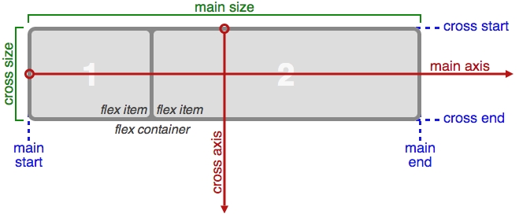

```python
widgets.IntSlider(description=r'\(\int_0^t f\)')
```

**利用layout函数，并且可以把某一个部件的layout给别的widget**

### Properties of the parent

- display

  display can be flex or inline-flex. This defines a flex container (block or inline).
- flex-flow

  flex-flow is a shorthand for the **flex-direction and flex-wrap** properties, which together define the flex container’s main and cross axes. Default is row nowrap.
  - flex-direction **(column-reverse | column | row | row-reverse )**

    This establishes the main-axis, thus defining the direction flex items are placed in the flex container. Flexbox is (aside from optional wrapping) a single-direction layout concept. Think of flex items as primarily laying out either in horizontal rows or vertical columns. Direction
  - flex-wrap **(nowrap | wrap | wrap-reverse)**

    By default, flex items will all try to fit onto one line. You can change that and allow the items to wrap as needed with this property. Direction also plays a role here, determining the direction new lines are stacked in. Wrap
- justify-content

  justify-content can be one of **flex-start, flex-end, center, space-between, space-around**. This defines the alignment **along the main axis**. It helps distribute extra free space left over when either all the flex items on a line are inflexible, or are flexible but have reached their maximum size. It also exerts some control over the alignment of items when they overflow the line. Justify
- align-items

  align-items can be one of **flex-start, flex-end, center, baseline, stretch.** This defines the default behaviour for how flex items are laid out **along the cross axis** on the current line. Think of it as the justify-content version for the cross-axis (perpendicular to the main-axis). Items
- align-content

  Note: **this property has no effect when there is only one line of flex items.**

### Properties of the items

The flexbox-related CSS properties of the items have no impact if the parent element is not a flexbox container (i.e. has a display attribute equal to flex or inline-flex).

- order

  By default, flex items are laid out in the source order. However, the order property controls the order in which they appear in the flex container. Order
- flex

  flex is shorthand for three properties, **flex-grow, flex-shrink and flex-basis** combined. The second and third parameters (flex-shrink and flex-basis) are optional. Default is **0 1 auto.**
  - flex-grow

    This defines the ability for a flex item to **grow if necessary.** It accepts a unitless value that serves as a proportion. It dictates what amount of the available space inside the flex container the item should take up.

    **If all items have flex-grow set to 1, the remaining space in the container will be distributed equally to all children. If one of the children a value of 2, the remaining space would take up twice as much space as the others (or it will try to, at least). Grow**
  - flex-shrink

    This defines the ability for a flex item to shrink if necessary.
  - flex-basis

    This defines **the default size** of an element before the remaining space is distributed. It can be a length (e.g. 20%, 5rem, etc.) or a keyword. The auto keyword means “look at my width or height property”.
- align-self

align-self allows the default alignment (or the one specified by align-items) to be overridden for individual flex items.

## grid layout

使用gridbox，把layout产给gridbox

### Properties of the parent

- grid-template-rows, grid-template-colums

  Defines the columns and rows of the grid with a space-separated list of values. The values represent the track size, and the space between them represents the grid line.

  Values:

  - can be a length, a percentage, or a fraction of the free space in the grid (using the fr unit)

  - an arbitrary name of your choosing
- grid-template-areas

  Defines a grid template by referencing the names of the grid areas which are specified with the grid-area property. Repeating the name of a grid area causes the content to span those cells. A period signifies an empty cell. The syntax itself provides a visualization of the structure of the grid.

  Values:

  ```
  <grid-area-name> - the name of a grid area specified with grid-area

  . - a period signifies an empty grid cell

  none - no grid areas are defined
  ```

- grid-gap

  A shorthand for grid-row-gap and grid-column-gap

  Values:

  ```
  <grid-row-gap>, <grid-column-gap> - length values
  ```

  where grid-row-gap and grid-column-gap specify the sizes of the grid lines. You can think of it like setting the width of the gutters between the columns / rows.

  ```
  <line-size> - a length value
  ```

  Note: The `grid-` prefix will be removed and `grid-gap` renamed to `gap`. The unprefixed property is already supported in Chrome 68+, Safari 11.2 Release 50+ and Opera 54+.
- align-items

  Aligns grid items along the block (column) axis (as opposed to justify-items which aligns along the inline (row) axis). This value applies to all grid items inside the container.
- justify-items

  Aligns grid items along the inline (row) axis (as opposed to align-items which aligns along the block (column) axis). This value applies to all grid items inside the container.
- align-content

  Sometimes the total size of your grid might be less than the size of its grid container. This could happen if all of your grid items are sized with non-flexible units like px. In this case you can set the alignment of the grid within the grid container. This property aligns the grid along the block (column) axis (as opposed to justify-content which aligns the grid along the inline (row) axis).
- justify-content

  Sometimes the total size of your grid might be less than the size of its grid container. This could happen if all of your grid items are sized with non-flexible units like px. In this case you can set the alignment of the grid within the grid container. This property aligns the grid along the inline (row) axis (as opposed to align-content which aligns the grid along the block (column) axis).
- grid-auto-columns, grid-auto-rows

  Specifies the size of any auto-generated grid tracks (aka implicit grid tracks). Implicit tracks get created when there are more grid items than cells in the grid or when a grid item is placed outside of the explicit grid. (see The Difference Between Explicit and Implicit Grids)

  Values:

  - can be a length, a percentage, or a fraction of the free space in the grid (using the fr unit)

### Properties of the items

Note: `float`, `display: inline-block`, `display: table-cell`, `vertical-align` and `column-??` properties have no effect on a grid item.

- grid-column, grid-row

  Determines a grid item’s location within the grid by referring to specific grid lines. grid-column-start/grid-row-start is the line where the item begins, and grid-column-end/grid-row-end is the line where the item ends.

  Values:

  ```
    <line> - can be a number to refer to a numbered grid line, or a name to refer to a named grid line

    span <number> - the item will span across the provided number of grid tracks

    span <name> - the item will span across until it hits the next line with the provided name

    auto - indicates auto-placement, an automatic span, or a default span of one
  ```

  If no grid-column / grid-row is declared, the item will span 1 track by default.

  Items can overlap each other. You can use **z-index** to control their stacking order.
- grid-area

  Gives an item a name so that it can be referenced by a template created with the grid-template-areas property. Alternatively, this property can be used as an even shorter shorthand for grid-row-start + grid-column-start + grid-row-end + grid-column-end.

  Values:

  ```
    <name> - a name of your choosing

    <row-start> / <column-start> / <row-end> / <column-end> - can be numbers or named lines
  ```

- justify-self

  Aligns a grid item inside a cell along the inline (row) axis (as opposed to align-self which aligns along the block (column) axis). This value applies to a grid item inside a single cell.

  To set alignment for all the items in a grid, this behavior can also be set on the grid container via the justify-items property.

## Predefined styles

If you wish the styling of widgets to make use of colors and styles defined by the environment (to be consistent with e.g. a notebook theme), many widgets enable choosing in a list of pre-defined styles.

For example, the Button widget has a button_style attribute that may take 5 different values:

```
'primary'

'success'

'info'

'warning'

'danger'
```

besides the default empty string **’’**.

```
from ipywidgets import Button

Button(description='Danger Button', button_style='danger')
```

### The style attribute

有style={}参数可以设置

While the layout attribute only exposes layout-related CSS properties for the top-level DOM element of widgets, the style attribute is used to expose non-layout related styling attributes of widgets.However, the properties of the style attribute are specific to each widget type.

```
b1 = Button(description='Custom color')
b1.style.button_color = 'lightgreen'
b1
```

You can get a list of the style attributes for a widget with the keys property.**b1.style.keys**

```
b1.style.keys
['_model_module',
 '_model_module_version',
 '_model_name',
 '_view_count',
 '_view_module',
 '_view_module_version',
 '_view_name',
 'button_color',
 'font_weight']
```

Just like the layout attribute, widget styles can be assigned to other widgets.

**可以把某一个widget的style传递给其他widget**

```
b2 = Button()
b2.style = b1.style
b2
```

Widget styling attributes are specific to each widget type.

```python
b1 = widgets.Button(description='Custom color')
b1.style.button_color = 'lightgreen'
b1
```

```python
widgets.Button(description='Custom color',style={'button_color':'lightgreen'})
```

## 布局实例

### flex

```python
from ipywidgets import Layout, Button, Box

items_layout = Layout( width='auto')     # override the default width of the button to 'auto' to let the button grow

box_layout = Layout(display='flex',
                    flex_flow='column',
                    align_items='stretch',
                    border='solid',
                    width='50%')

words = ['correct', 'horse', 'battery', 'staple']
items = [Button(description=word, layout=items_layout, button_style='danger') for word in words]
box = Box(children=items, layout=box_layout)
box
```

```python
from ipywidgets import Layout, Button, Box, VBox

# Items flex proportionally to the weight and the left over space around the text
items_auto = [
    Button(description='weight=1; auto', layout=Layout(flex='1 1 auto', width='auto'), button_style='danger'),
    Button(description='weight=3; auto', layout=Layout(flex='3 1 auto', width='auto'), button_style='danger'),
    Button(description='weight=1; auto', layout=Layout(flex='1 1 auto', width='auto'), button_style='danger'),
 ]

# Items flex proportionally to the weight
items_0 = [
    Button(description='weight=1; 0%', layout=Layout(flex='1 1 0%', width='auto'), button_style='danger'),
    Button(description='weight=3; 0%', layout=Layout(flex='3 1 0%', width='auto'), button_style='danger'),
    Button(description='weight=1; 0%', layout=Layout(flex='1 1 0%', width='auto'), button_style='danger'),
 ]
box_layout = Layout(display='flex',
                    flex_flow='row',
                    align_items='stretch',
                    width='70%')
box_auto = Box(children=items_auto, layout=box_layout)
box_0 = Box(children=items_0, layout=box_layout)
VBox([box_auto, box_0])
```

```python
from ipywidgets import Layout, Button, Box, FloatText, Textarea, Dropdown, Label, IntSlider

form_item_layout = Layout(
    display='flex',
    flex_flow='row',
    justify_content='space-between'
)

form_items = [
    Box([Label(value='Age of the captain'), IntSlider(min=40, max=60)], layout=form_item_layout),
    Box([Label(value='Egg style'),
         Dropdown(options=['Scrambled', 'Sunny side up', 'Over easy'])], layout=form_item_layout),
    Box([Label(value='Ship size'),
         FloatText()], layout=form_item_layout),
    Box([Label(value='Information'),
         Textarea()], layout=form_item_layout)
]

form = Box(form_items, layout=Layout(
    display='flex',
    flex_flow='column',
    border='solid 2px',
    align_items='stretch',
    width='50%'
))
form
```

```python
from ipywidgets import Layout, Button, VBox, Label

item_layout = Layout(height='100px', min_width='40px')
items = [Button(layout=item_layout, description=str(i), button_style='warning') for i in range(40)]
box_layout = Layout(overflow='scroll hidden',
                    border='3px solid black',
                    width='500px',
                    height='',
                    flex_flow='row',
                    display='flex')
carousel = Box(children=items, layout=box_layout)
VBox([Label('Scroll horizontally:'), carousel])
```

### grid

```python
from ipywidgets import Button, GridBox, Layout, ButtonStyle
header  = Button(description='Header',
                 layout=Layout(width='auto', grid_area='header'),
                 style={'button_color':'lightblue'})
main    = Button(description='Main',
                 layout=Layout(width='auto', grid_area='main'),
                 style=ButtonStyle(button_color='moccasin'))
sidebar = Button(description='Sidebar',
                 layout=Layout(width='auto', grid_area='sidebar'),
                 style=ButtonStyle(button_color='salmon'))
footer  = Button(description='Footer',
                 layout=Layout(width='auto', grid_area='footer'),
                 style=ButtonStyle(button_color='olive'))

GridBox(children=[header, main, sidebar, footer],
        layout=Layout(
            width='50%',
            grid_template_rows='auto auto auto',
            grid_template_columns='25% 25% 25% 25%',
            grid_template_areas='''
            "header header header header"
            "main main . sidebar "
            "footer footer footer footer"
            ''')
       )
```

```python
GridBox(children=[Button(layout=Layout(width='auto', height='auto'),
                         style=ButtonStyle(button_color='darkseagreen')) for i in range(9)
                 ],
        layout=Layout(
            width='50%',
            grid_template_columns='100px 50px 100px',
            grid_template_rows='80px auto 80px',
            grid_gap='5px 10px')
       )
```

## 调试并且创造布局

```python
from ipywidgets import Text,VBox,HBox,IntSlider
def f(**args):
    layout=Layout(
    width=str(args['width'])+'px',
    height=str(args['height'])+'px',
    grid_template_rows=args['p_gt_rows'],
    grid_template_columns=args['p_gt_columns'],
    grid_gap=str(args['vgap'])+'px'+' '+str(args['hgap'])+'px'
    #grid_template_areas='''{}'''.format,
    )
    a=GridBox(children=[Button(layout=Layout(width=args['child_width'], height=args['child_height']),
                         style=ButtonStyle(button_color='darkseagreen')) for i in range(9)
                 ],
        layout=layout
       )
    display(a)
it=widgets.IntText(start=100,end=1000,value=400,step=50,description='整个布局宽度')
it1=widgets.IntText(start=100,end=1000,value=400,step=50,description='整个布局高度')
t1=Text(description='item宽度',value='auto')
t2=Text(description='item长度',value='auto')
t3=Text(description='行布局',value='100px auto 100px')
t4=Text(description='列布局',value='80px auto 80px')
vgap=IntSlider(start=1,end=50,value=5,step=1,description='垂直间隔')
hgap=IntSlider(start=1,end=50,value=10,step=1,description='水平间隔')
s=VBox([it,it1,vgap,hgap,t1,t2,t3,t4])
w=widgets.interactive_output(f,{'width':it,'height':it1,'child_width':t1,'child_height':t2,'p_gt_rows':t3,'p_gt_columns':t4,'vgap':vgap,'hgap':hgap})
HBox([s,w])
```

```python
from ipywidgets import Text,IntSlider,VBox,HBox,Dropdown
from ipywidgets import interactive_output
def grid_arg(**args):
    #整体布局
    layout=Layout(
        width=args['width'],
        height=args['height'],
        grid_template_rows=args['grid_template_rows'],
        grid_template_columns=args['grid_template_columns'],
        grid_template_areas=args['grid_template_areas'],
        grid_gap=args['grid_gap'],
        align_items=args['align_items'],
        glign_content=args['align_content'],
        justify_items=args['justify_items'],
        justify_content=args['justify_content'],
        grid_auto_columns=args['grid_auto_columns'],
        grid_auto_rows=args['grid_auto_rows']
    )
    a=GridBox(children=[Button(layout=Layout(width='auto', height='auto'),
                         style=ButtonStyle(button_color='darkseagreen')) for i in range(9)
                 ],
        layout=layout
       )
    display(a)
width=Text(description='grid整体宽度',value='100%')
height=Text(description='grid整体高度',value='auto')
grid_template_columns=Text(description='列布局',value='100px auto 100px')
grid_template_rows=Text(description='行布局',value='80px auto 80px')
grid_template_areas=Text(description='item位置',value='''''')
grid_gap=Text(description='垂直间隔 水平间隔',value='5px 10px')
#align_items=Dropdown(options=['start','end','center','stretch'],value='stretch',description='一行文本的上下布局方式')
align_items=Dropdown(options=['flex-start', 'flex-end', 'center', 'baseline', 'stretch', 'inherit', 'initial', 'unset'],value='stretch',description='一行文本的上下布局方式')
#justify_items=Dropdown(options=['start','end','center','stretch'],value='stretch',description='一行文本的左右布局方式')
justify_items=Dropdown(options=['flex-start', 'flex-end', 'center', 'inherit', 'initial', 'unset'],value='initial',description='一行文本的左右布局方式')
align_content=Dropdown(options=['start','end','center','stretch','space-around','space-between','space-evenly'],value='stretch',description='多行文本的左右布局方式')
#justify_content=Dropdown(options=['start','end','center','stretch','space-around','space-between','space-evenly'],value='stretch',description='多行文本的上下布局方式')
justify_content=Dropdown(options=['flex-start', 'flex-end', 'center', 'space-between', 'space-around', 'inherit', 'initial', 'unset'],value='initial',description='多行文本的上下布局方式')
grid_auto_columns=Text(description='自动track的列大小',value='50px')
grid_auto_rows=Text(description='自动track的行大小',value='50px')

widget_container=VBox([width,height,grid_template_columns,grid_template_rows,grid_template_areas,grid_gap,
                       align_items,justify_items,align_content,justify_content,grid_auto_columns,grid_auto_rows],
                     layout=Layout(width='40%'))
w=interactive_output(grid_arg,{'width':width,'height':height,'grid_template_columns':grid_template_columns,'grid_template_rows':grid_template_rows,
                       'grid_template_areas':grid_template_areas,'grid_auto_columns':grid_auto_columns,'grid_auto_rows':grid_auto_rows,
                       'grid_gap':grid_gap,'align_items':align_items,'align_content':align_content,'justify_items':justify_items,
                        'justify_content':justify_content})
HBox([widget_container,w])
```

```python
def grid_item_arg(**args):
    #整体布局
    layout=Layout(
        width=args['width'],
        height=args['height'],
        grid_template_rows=args['grid_template_rows'],
        grid_template_columns=args['grid_template_columns'],
        grid_template_areas=args['grid_template_areas'],
        grid_gap=args['grid_gap'],
        align_items=args['align_items'],
        glign_content=args['align_content'],
        justify_items=args['justify_items'],
        justify_content=args['justify_content'],
        grid_auto_columns=args['grid_auto_columns'],
        grid_auto_rows=args['grid_auto_rows']
    )
    #每个item的布局
    layout_slider=Layout(
        grid_column=args['slider_grid_column'],
        grid_row=args['slider_grid_row'],
        grid_area=args['slider_grid_area'],
        justify_self=args['slider_justify_self'],
        align_self=args['slider_align_self'],
        width=args['slider_width'],
        height=args['slider_height']
    )
    layout_radiobuttons=Layout(
        grid_column=args['radiobuttons_grid_column'],
        grid_row=args['radiobuttons_grid_row'],
        grid_area=args['radiobuttons_grid_area'],
        justify_self=args['radiobuttons_justify_self'],
        align_self=args['radiobuttons_align_self'],
        width=args['radiobuttons_width'],
        height=args['radiobuttons_height']
    )
    layout_text=Layout(
        grid_column=args['text_grid_column'],
        grid_row=args['text_grid_row'],
        grid_area=args['text_grid_area'],
        justify_self=args['text_justify_self'],
        align_self=args['text_align_self'],
        width=args['text_width'],
        height=args['text_height']
    )
    layout_button=Layout(
        grid_column=args['button_grid_column'],
        grid_row=args['button_grid_row'],
        grid_area=args['button_grid_area'],
        justify_self=args['button_justify_self'],
        align_self=args['button_align_self'],
        width=args['button_width'],
        height=args['button_height']
    )
    #items
    slider=IntSlider(layout=layout_slider)
    radiobuttons=widgets.RadioButtons(options=['pepperoni', 'pineapple', 'anchovies'],value='pineapple',description='Pizza topping:',
    disabled=False,layout=layout_radiobuttons)
    text=widgets.Text(value='Hello World',placeholder='Type something',description='String:',disabled=False,layout=layout_text)
    button=widgets.Button(description='Click me',disabled=False,button_style='', # 'success', 'info', 'warning', 'danger' or ''
    tooltip='Click me',icon='check',layout=layout_button)
    #gridbox
    a=GridBox(children=[slider,radiobuttons,text,button],layout=layout)
    display(a)

#整体参数调试工具
width=Text(description='grid整体宽度',value='100%')
height=Text(description='grid整体高度',value='auto')
grid_template_columns=Text(description='列布局',value='100px auto 100px')
grid_template_rows=Text(description='行布局',value='80px auto 80px')
grid_template_areas=widgets.Textarea(description='item位置',value='''''')
grid_gap=Text(description='垂直间隔 水平间隔',value='5px 10px')
#align_items=Dropdown(options=['start','end','center','stretch'],value='stretch',description='一行文本的上下布局方式')
align_items=Dropdown(options=['flex-start', 'flex-end', 'center', 'baseline', 'stretch', 'inherit', 'initial', 'unset'],value='stretch',description='一行文本的上下布局方式')
#justify_items=Dropdown(options=['start','end','center','stretch'],value='stretch',description='一行文本的左右布局方式')
justify_items=Dropdown(options=['flex-start', 'flex-end', 'center', 'inherit', 'initial', 'unset'],value='initial',description='一行文本的左右布局方式')
align_content=Dropdown(options=['start','end','center','stretch','space-around','space-between','space-evenly'],value='stretch',description='多行文本的左右布局方式')
#justify_content=Dropdown(options=['start','end','center','stretch','space-around','space-between','space-evenly'],value='stretch',description='多行文本的上下布局方式')
justify_content=Dropdown(options=['flex-start', 'flex-end', 'center', 'space-between', 'space-around', 'inherit', 'initial', 'unset'],value='initial',description='多行文本的上下布局方式')
grid_auto_columns=Text(description='自动track的列大小',value='50px')
grid_auto_rows=Text(description='自动track的行大小',value='50px')

widget_container=VBox([width,height,grid_template_columns,grid_template_rows,grid_template_areas,grid_gap,
                       align_items,justify_items,align_content,justify_content,grid_auto_columns,grid_auto_rows],
                     layout=Layout(width='45%'))

dict_grid={'width':width,'height':height,'grid_template_columns':grid_template_columns,'grid_template_rows':grid_template_rows,
                       'grid_template_areas':grid_template_areas,'grid_auto_columns':grid_auto_columns,'grid_auto_rows':grid_auto_rows,
                       'grid_gap':grid_gap,'align_items':align_items,'align_content':align_content,'justify_items':justify_items,
                        'justify_content':justify_content}

#items对应工具的列表
slider_con=[]
radiobuttons_con=[]
text_con=[]
button_con=[]

item_arg=['grid_column','grid_row','grid_area','width','height','justify_self','align_self']
widget_pre=['slider','radiobuttons','text','button']
con=[slider_con,radiobuttons_con,text_con,button_con]
for ind,pre in enumerate(widget_pre):
    for j in item_arg[:5]:
        locals()[pre+'_'+j]=Text(description=pre+'_'+j,value='')
        con[ind].append(eval(pre+'_'+j))
    for k in item_arg[5:]:
        locals()[pre+'_'+k]=Dropdown(description=pre+'_'+k,options=['flex-start', 'flex-end', 'center', 'baseline', 'stretch', 'inherit', 'initial', 'unset'],value='stretch')
        con[ind].append(eval(pre+'_'+k))
item_widget=widgets.Accordion(children=[VBox(slider_con),VBox(radiobuttons_con),VBox(text_con),VBox(button_con)],layout=Layout(width='30%'))
[item_widget.set_title(i,title) for i,title in enumerate(widget_pre)]

dict_item={i+'_'+j:eval(i+'_'+j) for i in widget_pre for j in item_arg}

dict_item.update(dict_grid)

w=interactive_output(grid_item_arg,dict_item)

HBox([widget_container,item_widget,w])
```

```python
from IPython.display import display
def flex_arg(**args):
    layout=Layout(
    display=args['Display'],
    overflow=args['overflow'],
    height=args['height'],
    width=args['width'],
    border=args['border'],
    margin=args['margin'],
    align_items=args['align_items'],
    padding=args['padding'],
    flex_flow=args['flex_flow'],
    align_content=args['align_content'],
    justify_content=args['justify_content']
    )
    red_layout=Layout(
    width=args['red_width'],
    height=args['red_height'],
    order=args['red_order'],
    flex=args['red_flex'],
    align_self=args['red_align_self']
    )
    blue_layout=Layout(
    width=args['blue_width'],
    height=args['blue_height'],
    order=args['blue_order'],
    flex=args['blue_flex'],
    align_self=args['blue_align_self']
    )
    yellow_layout=Layout(
    width=args['yellow_width'],
    height=args['yellow_height'],
    order=args['yellow_order'],
    flex=args['yellow_flex'],
    align_self=args['yellow_align_self']
    )
    green_layout=Layout(
    width=args['green_width'],
    height=args['green_height'],
    order=args['green_order'],
    flex=args['green_flex'],
    align_self=args['green_align_self']
    )
    children=[Button(layout=lay,tooltips=color,style=ButtonStyle(button_color=color)) for color,lay in zip(['red','blue','yellow','green'],[red_layout,blue_layout,yellow_layout,green_layout])]
    w=widgets.Box(children=children,layout=layout)
    display(w)

#整体参数调试工具
width=Text(description='grid整体宽度',value='100%')
height=Text(description='grid整体高度',value='auto')
Display=Dropdown(description='display',options=['flex','inline-flex'],value='flex')
overflow=Dropdown(description='overflow',options=['scroll hidden','ni'],value='scroll hidden')
border=Text(description='border',value='')
margin=Text(description='margin',value='')
padding=Text(description='padding',value='')
flex_flow=Text(description='flex_flow',value='',placeholder='flex-direction flex-wrap')# (column-reverse | column | row | row-reverse ),(nowrap | wrap | wrap-reverse)
align_content=Dropdown(description='align_content',value='stretch',options=['flex-start', 'flex-end', 'center', 'baseline', 'stretch'])
judtify_content=Dropdown(description='justify_content',value='initial',options=['flex-start', 'flex-end', 'center', 'space-between', 'space-around', 'inherit', 'initial', 'unset'])
align_items=Dropdown(description='align_items',value='stretch',options=['flex-start', 'flex-end', 'center', 'baseline', 'stretch'])

widget_container=VBox([width,height,Display,overflow,border,margin,padding,flex_flow,align_content,align_items,justify_content],
                     layout=Layout(width='45%'))

dict_grid={'width':width,'height':height,'Display':Display,'overflow':overflow,'border':border,'margin':margin,'padding':padding,'flex_flow':flex_flow,'align_content':align_content,'justify_content':justify_content,'align_items':align_items}

#items对应工具的列表
red_con=[]
blue_con=[]
yellow_con=[]
green_con=[]

item_arg=['width','height','order','flex','align_self']
widget_pre=['red','blue','yellow','green']
con=[red_con,blue_con,yellow_con,green_con]
for ind,pre in enumerate(widget_pre):
    for j in item_arg[:4]:
        locals()[pre+'_'+j]=Text(description=pre+'_'+j,value='')
        con[ind].append(eval(pre+'_'+j))
    for k in item_arg[4:]:
        locals()[pre+'_'+k]=Dropdown(description=pre+'_'+k,options=['flex-start', 'flex-end', 'center', 'baseline', 'stretch', 'inherit', 'initial', 'unset'],value='stretch')
        con[ind].append(eval(pre+'_'+k))
item_widget=widgets.Accordion(children=[VBox(red_con),VBox(blue_con),VBox(yellow_con),VBox(green_con)],layout=Layout(width='30%'))
[item_widget.set_title(i,title) for i,title in enumerate(widget_pre)]

dict_item={i+'_'+j:eval(i+'_'+j) for i in widget_pre for j in item_arg}

dict_item.update(dict_grid)

w=interactive_output(flex_arg,dict_item)

HBox([widget_container,item_widget,w])
```

# 实践应用

```python
import pymysql
import pandas as pd
import numpy as np
from bokeh.plotting import figure,show
from bokeh.io import output_notebook
from bokeh.models import DataTable
from bokeh.models import ColumnDataSource,TableColumn
import ipywidgets as widgets
from IPython.display import display
```

```python
output_notebook()
```

```python
conn=pymysql.connect(host='localhost',port=3306,user='schoolbuilder',db='school')
cursor=conn.cursor(cursor=pymysql.cursors.DictCursor)
cursor.execute("select * from student_information")
student_info=pd.DataFrame(cursor.fetchall())
cursor.execute("select * from class")
class_info=pd.DataFrame(cursor.fetchall())
cursor.execute("select * from teacher_information")
teacher_info=pd.DataFrame(cursor.fetchall())
cursor.execute("select * from subject")
subject_info=pd.DataFrame(cursor.fetchall())
cursor.execute("select * from chengji_information")
chengji_info=pd.DataFrame(cursor.fetchall())
```

```python
StudentID=widgets.Dropdown(options=list(student_info['bf_StudentID'].unique())+['ALL'],value='ALL',layout=widgets.Layout(width='auto'))
cla_term=widgets.Dropdown(options=list(student_info['cla_term'].unique())+['ALL'],value='ALL',layout=widgets.Layout(width='auto'))
sid=widgets.Text(value='',continuous_update=False)
out=widgets.Output()
@out.capture(clear_output=True,wait=True)
def f_Student(StudentID,cla_term):
    a=student_info
    if StudentID!='ALL':
        a=student_info[student_info['bf_StudentID']==StudentID]
    b=a
    if cla_term!='ALL':
        b=a[a['cla_term']==cla_term]
    source=ColumnDataSource(b)
    columns = [TableColumn(field=i, title=i) for i in list(b.columns)]
    data_table = DataTable(source=source, columns=columns, width=800, height=280)
    show(data_table)
def update_cla_term(change):
    if change['new']=='ALL':
        cla_term.options=list(student_info['cla_term'].unique())+['ALL']
    else:
        options=list(student_info[student_info['bf_StudentID']==change['new']]['cla_term'].unique())
        cla_term.options=options+['ALL']
def update_StudentID(change):
    StudentID.value=change['new']
sid.observe(update_StudentID,'value')
StudentID.observe(update_cla_term,'value')
vbox=widgets.VBox(children=[StudentID,cla_term,sid],layout=widgets.Layout(width='30%'))
w=widgets.interactive_output(f_Student,{'StudentID':StudentID,'cla_term':cla_term})
tab_student=widgets.HBox([vbox,out])
#tab_student
```

```python
#Teacher=widgets.VBox(children=[subject,TeacherID])#只有一个term
subject=widgets.Dropdown(options=list(zip(subject_info.sub_Name,subject_info.sub_id))+[('ALL','ALL')],value='ALL')
TeacherID=widgets.Dropdown(options=list(teacher_info.bas_id.unique())+['ALL'],value='ALL')
def upgrate_teacher_id(change):
    if change['new']=='ALL':
        TeacherID.options=list(teacher_info.bas_id.unique())+['ALL']
    else:
        TeacherID.options=list(teacher_info[teacher_info['sub_id']==change['new']]['bas_id'].unique())+['ALL']
    TeacherID.value='ALL'
subject.observe(upgrate_teacher_id,'value')
out_teacher=widgets.Output()
@out_teacher.capture(clear_output=True,wait=True)
def f_teacher(subject,TeacherID):
    a=teacher_info
    if subject!='ALL':
        a=teacher_info[teacher_info['sub_id']==subject]
    b=a
    if TeacherID!='ALL':
        b=a[a['bas_id']==TeacherID]
    source=ColumnDataSource(b)
    columns = [TableColumn(field=i, title=i) for i in list(b.columns)]
    data_table = DataTable(source=source, columns=columns, width=500, height=280)
    show(data_table)
vbox_teacher=widgets.VBox(children=[subject,TeacherID],layout=widgets.Layout(width='40%'))
w_teacher=widgets.interactive_output(f_teacher,{'subject':subject,'TeacherID':TeacherID})
tab_teacher=widgets.HBox([vbox_teacher,out_teacher])
#tab_teacher
```

```python
from bokeh.layouts import column
# Class=widgets.VBox(children=[grad,ClassID1])
grad=widgets.Dropdown(options=list(class_info.gra_Name.unique()),value='高一')#不需要看所有年级
ClassID=widgets.Dropdown(options=list(zip(class_info.cla_Name.unique(),class_info.cla_id.unique()))+[('ALL','ALL')],value='ALL')
def upgrade_class(change):
    a=class_info[class_info.gra_Name==change['new']]
    ClassID.options=list(zip(a.cla_Name.unique(),a.cla_id.unique()))+[('ALL','ALL')]
    ClassID.value='ALL'
grad.observe(upgrade_class,'value')
out_class=widgets.Output()
@out_class.capture(clear_output=True,wait=True)
def f_class(grad,ClassID):
    a=class_info
    a=a[a['gra_Name']==grad]
    if ClassID!='ALL':
        a=a[a['cla_id']==ClassID]
        data=student_info[student_info.cla_id==ClassID]
        source1=ColumnDataSource(a)
        columns1 = [TableColumn(field=i, title=i) for i in list(a.columns)]
        data_table1 = DataTable(source=source1, columns=columns1, width=500, height=100)
        source2=ColumnDataSource(data)
        columns2 = [TableColumn(field=i, title=i) for i in list(data.columns)]
        data_table2= DataTable(source=source2, columns=columns2, width=500, height=280)
        show(column([data_table1,data_table2]))
    else:
        source1=ColumnDataSource(a)
        columns1 = [TableColumn(field=i, title=i) for i in list(a.columns)]
        data_table1 = DataTable(source=source1, columns=columns1, width=500, height=280)
        show(data_table1)
vbox_class=widgets.VBox(children=[grad,ClassID],layout=widgets.Layout(width='40%'))
w_class=widgets.interactive_output(f_class,{'grad':grad,'ClassID':ClassID})
tab_class=widgets.HBox([vbox_class,out_class])
#tab_class
```

```python
#StudentID=widgets.Dropdown(options=list(student_info['bf_StudentID'].unique())+['ALL'],value='ALL',layout=widgets.Layout(width='auto'))
#grad=widgets.Dropdown(options=list(class_info.gra_Name.unique()),value='高一')#不需要看所有年级
#ClassID=widgets.Dropdown(options=list(zip(class_info.cla_Name.unique(),class_info.cla_id.unique()))+[('ALL','ALL')],value='ALL')
def update_StudentID(change):
    if change['new']!='ALL':
        data=student_info[student_info.cla_id==change['new']]
        StudentID.options=list(data.bf_StudentID.unique())+['ALL']
        StudentID.value='ALL'
    else:
        a=list(class_info[class_info['gra_Name']==grad.value]['cla_id'].unique())
        l=[list(student_info[student_info.cla_id==i].bf_StudentID.unique()) for i in a]
        l=[j for j in k for k in l]
        StudentID.options=l+['ALL']
        StudentID.value='ALL'
ClassID.observe(update_StudentID,'value')
ExamID=widgets.Dropdown(options=list(zip(chengji_info.exam_numname.unique(),chengji_info.exam_number.unique()))+[('ALL','ALL')],value='ALL')
#subject=widgets.Dropdown(options=list(zip(subject_info.sub_Name,subject_info.sub_id))+[('ALL','ALL')],value='ALL')
def update_subject(change):
    if change['new']!='ALL':
        data=chengji_info[chengji_info['exam_number']==change['new']]
        name=[list(subject_info[subject_info['sub_id']==i].sub_Name) for i in list(data['mes_sub_id'].unique())]
        name=[j[0] for j in name]
        subject.options=list(zip(name,list(data['mes_sub_id'].unique())))+[('ALL','ALL')]
        subject.value='ALL'
ExamID.observe(update_subject,'value')
out_chengji=widgets.Output()
@out_chengji.capture(clear_output=True,wait=True)
def f_chengji(Student_ID,ExamID,subject):
    c=chengji_info
    if Student_ID!='ALL':
        c=c[c['mes_StudentID']==Student_ID]
    else:
        op=StudentID.options[:-1]#这里应为要用到全局变量，所要参数设置不能再同名
        bo=[i in op for i in c.mes_StudentID]
        c=c[bo]
    if ExamID!='ALL':
        c=c[c['exam_number']==ExamID]
    if subject!='ALL':
        c=c[c['mes_sub_id']==subject]
    source=ColumnDataSource(c)
    columns=[TableColumn(field=i, title=i) for i in list(c.columns)]
    data_table= DataTable(source=source,columns=columns,width=600, height=280)
    show(data_table)
vbox_chengji=widgets.VBox([grad,ClassID,StudentID,ExamID,subject],layout=widgets.Layout(width='30%'))
w_chengji=widgets.interactive_output(f_chengji,{'Student_ID':StudentID,'ExamID':ExamID,'subject':subject})
tab_chengji=widgets.HBox([vbox_chengji,out_chengji])
#tab_chengji
```

```python
data=chengji_info[chengji_info['exam_number']=='301']
name=[list(subject_info[subject_info['sub_id']==i].sub_Name) for i in list(data['mes_sub_id'].unique())]
#name
#name1=[i for i in j for j in name]
#name1很奇怪
```

```python
# student

StudentID=widgets.Dropdown(options=list(student_info['bf_StudentID'].unique())+['ALL'],value='ALL',layout=widgets.Layout(width='auto'))
cla_term=widgets.Dropdown(options=list(student_info['cla_term'].unique())+['ALL'],value='ALL',layout=widgets.Layout(width='auto'))
sid=widgets.Text(value='',continuous_update=False)
out=widgets.Output()
@out.capture(clear_output=True,wait=True)
def f_Student(StudentID,cla_term):
    a=student_info
    if StudentID!='ALL':
        a=student_info[student_info['bf_StudentID']==StudentID]
    b=a
    if cla_term!='ALL':
        b=a[a['cla_term']==cla_term]
    source=ColumnDataSource(b)
    columns = [TableColumn(field=i, title=i) for i in list(b.columns)]
    data_table = DataTable(source=source, columns=columns, width=800, height=280)
    show(data_table)
def update_cla_term(change):
    if change['new']=='ALL':
        cla_term.options=list(student_info['cla_term'].unique())+['ALL']
    else:
        options=list(student_info[student_info['bf_StudentID']==change['new']]['cla_term'].unique())
        cla_term.options=options+['ALL']
def update_StudentID(change):
    StudentID.value=change['new']
sid.observe(update_StudentID,'value')
StudentID.observe(update_cla_term,'value')
vbox=widgets.VBox(children=[StudentID,cla_term,sid],layout=widgets.Layout(width='30%'))
w=widgets.interactive_output(f_Student,{'StudentID':StudentID,'cla_term':cla_term})
tab_student=widgets.HBox([vbox,out])

# teacher

#Teacher=widgets.VBox(children=[subject,TeacherID])#只有一个term
subject=widgets.Dropdown(options=list(zip(subject_info.sub_Name,subject_info.sub_id))+[('ALL','ALL')],value='ALL')
TeacherID=widgets.Dropdown(options=list(teacher_info.bas_id.unique())+['ALL'],value='ALL')
def upgrate_teacher_id(change):
    if change['new']=='ALL':
        TeacherID.options=list(teacher_info.bas_id.unique())+['ALL']
    else:
        TeacherID.options=list(teacher_info[teacher_info['sub_id']==change['new']]['bas_id'].unique())+['ALL']
    TeacherID.value='ALL'
subject.observe(upgrate_teacher_id,'value')
out_teacher=widgets.Output()
@out_teacher.capture(clear_output=True,wait=True)
def f_teacher(subject,TeacherID):
    a=teacher_info
    if subject!='ALL':
        a=teacher_info[teacher_info['sub_id']==subject]
    b=a
    if TeacherID!='ALL':
        b=a[a['bas_id']==TeacherID]
    source=ColumnDataSource(b)
    columns = [TableColumn(field=i, title=i) for i in list(b.columns)]
    data_table = DataTable(source=source, columns=columns, width=500, height=280)
    show(data_table)
vbox_teacher=widgets.VBox(children=[subject,TeacherID],layout=widgets.Layout(width='40%'))
w_teacher=widgets.interactive_output(f_teacher,{'subject':subject,'TeacherID':TeacherID})
tab_teacher=widgets.HBox([vbox_teacher,out_teacher])

# class

from bokeh.layouts import column
# Class=widgets.VBox(children=[grad,ClassID1])
grad=widgets.Dropdown(options=list(class_info.gra_Name.unique()),value='高一')#不需要看所有年级
ClassID=widgets.Dropdown(options=list(zip(class_info.cla_Name.unique(),class_info.cla_id.unique()))+[('ALL','ALL')],value='ALL')
def upgrade_class(change):
    a=class_info[class_info.gra_Name==change['new']]
    ClassID.options=list(zip(a.cla_Name.unique(),a.cla_id.unique()))+[('ALL','ALL')]
    ClassID.value='ALL'
grad.observe(upgrade_class,'value')
out_class=widgets.Output()
@out_class.capture(clear_output=True,wait=True)
def f_class(grad,ClassID):
    a=class_info
    a=a[a['gra_Name']==grad]
    if ClassID!='ALL':
        a=a[a['cla_id']==ClassID]
        data=student_info[student_info.cla_id==ClassID]
        source1=ColumnDataSource(a)
        columns1 = [TableColumn(field=i, title=i) for i in list(a.columns)]
        data_table1 = DataTable(source=source1, columns=columns1, width=500, height=100)
        source2=ColumnDataSource(data)
        columns2 = [TableColumn(field=i, title=i) for i in list(data.columns)]
        data_table2= DataTable(source=source2, columns=columns2, width=500, height=280)
        show(column([data_table1,data_table2]))
    else:
        source1=ColumnDataSource(a)
        columns1 = [TableColumn(field=i, title=i) for i in list(a.columns)]
        data_table1 = DataTable(source=source1, columns=columns1, width=500, height=280)
        show(data_table1)
vbox_class=widgets.VBox(children=[grad,ClassID],layout=widgets.Layout(width='40%'))
w_class=widgets.interactive_output(f_class,{'grad':grad,'ClassID':ClassID})
tab_class=widgets.HBox([vbox_class,out_class])

# chengji

#StudentID=widgets.Dropdown(options=list(student_info['bf_StudentID'].unique())+['ALL'],value='ALL',layout=widgets.Layout(width='auto'))
#grad=widgets.Dropdown(options=list(class_info.gra_Name.unique()),value='高一')#不需要看所有年级
#ClassID=widgets.Dropdown(options=list(zip(class_info.cla_Name.unique(),class_info.cla_id.unique()))+[('ALL','ALL')],value='ALL')
def update_StudentID(change):
    if change['new']!='ALL':
        data=student_info[student_info.cla_id==change['new']]
        StudentID.options=list(data.bf_StudentID.unique())+['ALL']
        StudentID.value='ALL'
    else:
        a=list(class_info[class_info['gra_Name']==grad.value]['cla_id'].unique())
        l=[list(student_info[student_info.cla_id==i].bf_StudentID.unique()) for i in a]
        name_stu=[]
        for i in l:
            for j in i:
                name_stu.append(j)
        StudentID.options=name_stu+['ALL']
        StudentID.value='ALL'
ClassID.observe(update_StudentID,'value')
ExamID=widgets.Dropdown(options=list(zip(chengji_info.exam_numname.unique(),chengji_info.exam_number.unique()))+[('ALL','ALL')],value='ALL')
#subject=widgets.Dropdown(options=list(zip(subject_info.sub_Name,subject_info.sub_id))+[('ALL','ALL')],value='ALL')
def update_subject(change):
    if change['new']!='ALL':
        data=chengji_info[chengji_info['exam_number']==change['new']]
        name=[list(subject_info[subject_info['sub_id']==i].sub_Name) for i in list(data['mes_sub_id'].unique())]
        name=[j[0] for j in name]
        subject.options=list(zip(name,list(data['mes_sub_id'].unique())))+[('ALL','ALL')]
        subject.value='ALL'
ExamID.observe(update_subject,'value')
out_chengji=widgets.Output()
@out_chengji.capture(clear_output=True,wait=True)
def f_chengji(Student_ID,ExamID,subject):
    c=chengji_info
    if Student_ID!='ALL':
        c=c[c['mes_StudentID']==Student_ID]
    else:
        op=StudentID.options[:-1]#这里应为要用到全局变量，所要参数设置不能再同名
        bo=[i in op for i in c.mes_StudentID]
        c=c[bo]
    if ExamID!='ALL':
        c=c[c['exam_number']==ExamID]
    if subject!='ALL':
        c=c[c['mes_sub_id']==subject]
    source=ColumnDataSource(c)
    columns=[TableColumn(field=i, title=i) for i in list(c.columns)]
    data_table= DataTable(source=source,columns=columns,width=600, height=280)
    show(data_table)
vbox_chengji=widgets.VBox([grad,ClassID,StudentID,ExamID,subject],layout=widgets.Layout(width='30%'))
w_chengji=widgets.interactive_output(f_chengji,{'Student_ID':StudentID,'ExamID':ExamID,'subject':subject})
tab_chengji=widgets.HBox([vbox_chengji,out_chengji])

#合并到tab中
tab=widgets.Tab(children=[tab_student,tab_teacher,tab_class,tab_chengji])
tab.set_title(0,'Student')
tab.set_title(1,'Teacher')
tab.set_title(2,'Class')
tab.set_title(3,'chengji')
tab
```